# Project: Investigation of Soccer Players' Performance

- Introduction
- Data Wrangling
- Exploratory Data Analysis
- Conclusions

## Introduction

### Dataset Description

I've selected the European Soccer Database to investigate, due to my passion on understanding performance. This database includes information related to soccer for seasons 2008 to 2016. I've opened the file using DB Browser, since it's a ".sqlite" file. Within DB Browser I was able to better check the contents of the database (in "Browse Data"), which includes 8 tables, with the following information:

- `Country` (mentions included countries)
- `League` (mentions included leagues and their respective countries)
- `Match` (info about soccer matches, of where and when they occurred, which teams and players played, players' positions in the field, scores, stats related to team performance during the game, the odds of winning, drawing or losing by 10 different providers)
- `Player` (mentions included players, their birthday, height and weight)
- `Player_Attributes` (info about each player in terms of their attributes, such as overall rating, potential, preferred foot, rate of attacking and defensive work, scores related to how good they are in various skills and general attributes, and when these measures were updated)
- `Team` (mentions included teams)
- `Team_Attributes` (info about each team like their scores in various attributes and its respective class, and when these measures were updated)
- `sqlite_sequence` (unrelated to soccer information and unnecessary for this investigation)

### Questions for Analysis

Taking into account all information we have and my own curiosity, I've come up with 3 questions:

1. **How do team results tend to differ by team overall age?**

This is a type of question very common in recruitment processes, because there is a lot of preconceived ideas about age in certain tasks' performance. I am curious to know if, for example, there are age differences in winning and losing teams.

1. **How do team results tend to differ by team overall weight?**

Is it possible that teams have different results depending on their weight?

1. **How do team results tend to differ by team overall height?**

Does height seem to be an advantage, disadvantage or irrelevant? (although this is not a study about causation, but I'm pointing out the origin of my motivation to these questions, so it would be a starting point)

```python
# These are the packages I am expecting to use to answer all questions

import pandas as pd
import numpy as np
import matplotlib.pyplot as plt
%matplotlib inline
```

## Data Wrangling

In order to answer my questions, I'll only need the tables `Match` and `Player`. For that reason, I've exported these 2 tables, with only the columns I believe to be necessary in the `Player` table (I'll clean the `Match` table as necessary), and I'll merge them whenever necessary using python. I've used the following SQL code to do it:

> SELECT * FROM Match

> SELECT player_api_id, birthday, height, weight FROM Player

I downloaded the respective CSV files.

### General Properties

Let's look at the data to better understand it.

```python
#Load and see Match information
df_match = pd.read_csv("Football_Match.csv")
df_match.head(1)
```

|  | id | country_id | league_id | season | stage | date | match_api_id | home_team_api_id | away_team_api_id | home_team_goal | ... | SJA | VCH | VCD | VCA | GBH | GBD | GBA | BSH | BSD | BSA |
| --- | --- | --- | --- | --- | --- | --- | --- | --- | --- | --- | --- | --- | --- | --- | --- | --- | --- | --- | --- | --- | --- |
| 0 | 1 | 1 | 1 | 2008/2009 | 1 | 2008-08-17 00:00:00 | 492473 | 9987 | 9993 | 1 | ... | 4.0 | 1.65 | 3.4 | 4.5 | 1.78 | 3.25 | 4.0 | 1.73 | 3.4 | 4.2 |

1 rows × 115 columns

```python
#See Match column names (too many columns, not able to use info())
df_match.columns.values
```

```
array(['id', 'country_id', 'league_id', 'season', 'stage', 'date',
       'match_api_id', 'home_team_api_id', 'away_team_api_id',
       'home_team_goal', 'away_team_goal', 'home_player_X1',
       'home_player_X2', 'home_player_X3', 'home_player_X4',
       'home_player_X5', 'home_player_X6', 'home_player_X7',
       'home_player_X8', 'home_player_X9', 'home_player_X10',
       'home_player_X11', 'away_player_X1', 'away_player_X2',
       'away_player_X3', 'away_player_X4', 'away_player_X5',
       'away_player_X6', 'away_player_X7', 'away_player_X8',
       'away_player_X9', 'away_player_X10', 'away_player_X11',
       'home_player_Y1', 'home_player_Y2', 'home_player_Y3',
       'home_player_Y4', 'home_player_Y5', 'home_player_Y6',
       'home_player_Y7', 'home_player_Y8', 'home_player_Y9',
       'home_player_Y10', 'home_player_Y11', 'away_player_Y1',
       'away_player_Y2', 'away_player_Y3', 'away_player_Y4',
       'away_player_Y5', 'away_player_Y6', 'away_player_Y7',
       'away_player_Y8', 'away_player_Y9', 'away_player_Y10',
       'away_player_Y11', 'home_player_1', 'home_player_2',
       'home_player_3', 'home_player_4', 'home_player_5', 'home_player_6',
       'home_player_7', 'home_player_8', 'home_player_9',
       'home_player_10', 'home_player_11', 'away_player_1',
       'away_player_2', 'away_player_3', 'away_player_4', 'away_player_5',
       'away_player_6', 'away_player_7', 'away_player_8', 'away_player_9',
       'away_player_10', 'away_player_11', 'goal', 'shoton', 'shotoff',
       'foulcommit', 'card', 'cross', 'corner', 'possession', 'B365H',
       'B365D', 'B365A', 'BWH', 'BWD', 'BWA', 'IWH', 'IWD', 'IWA', 'LBH',
       'LBD', 'LBA', 'PSH', 'PSD', 'PSA', 'WHH', 'WHD', 'WHA', 'SJH',
       'SJD', 'SJA', 'VCH', 'VCD', 'VCA', 'GBH', 'GBD', 'GBA', 'BSH',
       'BSD', 'BSA'], dtype=object)
```

```python
#Load and see Player information
df_player = pd.read_csv("Football_Player.csv")
df_player.head(1)
```

|  | player_api_id | birthday | height | weight |
| --- | --- | --- | --- | --- |
| 0 | 505942 | 1992-02-29 00:00:00 | 182.88 | 187 |

```python
#See Player columns and their datatypes
df_player.info()
```

```
<class 'pandas.core.frame.DataFrame'>
RangeIndex: 11060 entries, 0 to 11059
Data columns (total 4 columns):
 #   Column         Non-Null Count  Dtype
---  ------         --------------  -----
 0   player_api_id  11060 non-null  int64
 1   birthday       11060 non-null  object
 2   height         11060 non-null  float64
 3   weight         11060 non-null  int64
dtypes: float64(1), int64(2), object(1)
memory usage: 345.8+ KB
```

Now I know all columns within the original tables. I won't explore them just yet, since there are too many. I'll first create tables with only the needed columns and then do Data Exploration Analysis within those.

### Data Cleaning

First, let's create the dataframe we need for the first question. We need it to have something like the following columns:

- `match_api_id`
- `team_api_id`
- `Overall_Age`
- `Overall_Height`
- `Overall_Weight`
- `Win_Rate`
- `Draw_Rate`
- `Loss_Rate`

Although we'll also include the goals scored and suffered to see if there are also differences in terms of that performance.

```python
# I know I'll have to change datatype of birthday in Player, but I need to know the datetype of date in Match too
df_match["date"].dtypes
```

```
dtype('O')
```

```python
# We need to change datatype of birthdate in Player and in date of Match
df_player["birthday"] = pd.to_datetime(df_player["birthday"])
df_match["date"] = pd.to_datetime(df_match["date"])
```

```python
# Now we need to know the average age. We'll get the average age of the team per match, first.
#This list will help
home_team=['home_player_1','home_player_2','home_player_3','home_player_4','home_player_5','home_player_6','home_player_7','home_player_8','home_player_9','home_player_10','home_player_11']
away_team=['away_player_1','away_player_2','away_player_3','away_player_4','away_player_5','away_player_6','away_player_7','away_player_8','away_player_9','away_player_10','away_player_11']

# Let's drop missing values on players id before we go on
df_match.dropna(subset=home_team, inplace=True)
df_match.dropna(subset=away_team, inplace=True)
```

```python
# Now we'll focus on preparing our table for question1
match_columns1 = ["date","match_api_id","home_team_api_id","away_team_api_id","home_team_goal","away_team_goal"]
match_columns_final = match_columns1 + home_team + away_team
df_questions = df_match.loc[:,match_columns_final]
df_questions.info()
```

```
<class 'pandas.core.frame.DataFrame'>
Int64Index: 21374 entries, 145 to 25978
Data columns (total 28 columns):
 #   Column            Non-Null Count  Dtype
---  ------            --------------  -----
 0   date              21374 non-null  datetime64[ns]
 1   match_api_id      21374 non-null  int64
 2   home_team_api_id  21374 non-null  int64
 3   away_team_api_id  21374 non-null  int64
 4   home_team_goal    21374 non-null  int64
 5   away_team_goal    21374 non-null  int64
 6   home_player_1     21374 non-null  float64
 7   home_player_2     21374 non-null  float64
 8   home_player_3     21374 non-null  float64
 9   home_player_4     21374 non-null  float64
```

[output cut: 20 more lines]

```python
# Now we're going to get the birthday information for each home player
for number in range(11):
    df_questions = df_questions.merge(df_player, left_on="home_player_"+str(number+1), right_on="player_api_id", how="left", suffixes=(None,"_h"+str(number+1)))
    df_questions.drop("player_api_id", axis=1, inplace=True)

df_questions.rename(columns={"birthday":"birthday_h1","height":"height_h1","weight":"weight_h1"}, inplace=True)
```

```python
# And now for each away player
for number in range(11):
    df_questions = df_questions.merge(df_player, left_on="away_player_"+str(number+1), right_on="player_api_id", how="left", suffixes=(None,"_a"+str(number+1)))
    df_questions.drop("player_api_id", axis=1, inplace=True)

df_questions.rename(columns={"birthday":"birthday_a1","height":"height_a1","weight":"weight_a1"}, inplace=True)
```

```python
# Let's convert players' birthday with the age they had at the day of the match.
#Starting with home_players
for number in range(11):
    df_questions["birthday_h"+str(number+1)] = df_questions["date"] - df_questions["birthday_h"+str(number+1)]
    df_questions["birthday_h"+str(number+1)] = (df_questions["birthday_h"+str(number+1)] / np.timedelta64(1,'Y'))

# We could convert it to int, by ending with .astype(int), but float is a better representation
#and we'll want the averages so it will end up as float anyway.
```

```python
#Now with away_players
for number in range(11):
    df_questions["birthday_a"+str(number+1)] = df_questions["date"] - df_questions["birthday_a"+str(number+1)]
    df_questions["birthday_a"+str(number+1)] = (df_questions["birthday_a"+str(number+1)] / np.timedelta64(1,'Y'))
```

```python
# We need a list of ages, weights and heights to know their averages per match. Let's create those lists next
h_age_columns=['birthday_h1','birthday_h2','birthday_h3','birthday_h4','birthday_h5','birthday_h6','birthday_h7','birthday_h8','birthday_h9','birthday_h10','birthday_h11']
a_age_columns=['birthday_a1','birthday_a2','birthday_a3','birthday_a4','birthday_a5','birthday_a6','birthday_a7','birthday_a8','birthday_a9','birthday_a10','birthday_a11']
h_weight_columns=['weight_h1','weight_h2','weight_h3','weight_h4','weight_h5','weight_h6','weight_h7','weight_h8','weight_h9','weight_h10','weight_h11']
a_weight_columns=['weight_a1','weight_a2','weight_a3','weight_a4','weight_a5','weight_a6','weight_a7','weight_a8','weight_a9','weight_a10','weight_a11']
h_height_columns=['height_h1','height_h2','height_h3','height_h4','height_h5','height_h6','height_h7','height_h8','height_h9','height_h10','height_h11']
a_height_columns=['height_a1','height_a2','height_a3','height_a4','height_a5','height_a6','height_a7','height_a8','height_a9','height_a10','height_a11']
```

```python
# Get the age average per match
df_questions["home_age_avg"] = df_questions[h_age_columns].mean(axis=1)
df_questions["away_age_avg"] = df_questions[a_age_columns].mean(axis=1)

# The weight average per match
df_questions["home_weight_avg"] = df_questions[h_weight_columns].mean(axis=1)
df_questions["away_weight_avg"] = df_questions[a_weight_columns].mean(axis=1)

# The height average per match
df_questions["home_height_avg"] = df_questions[h_height_columns].mean(axis=1)
df_questions["away_height_avg"] = df_questions[a_height_columns].mean(axis=1)
```

```python
df_questions.head()
```

|  | date | match_api_id | home_team_api_id | away_team_api_id | home_team_goal | away_team_goal | home_player_1 | home_player_2 | home_player_3 | home_player_4 | ... | weight_a10 | birthday_a11 | height_a11 | weight_a11 | home_age_avg | away_age_avg | home_weight_avg | away_weight_avg | home_height_avg | away_height_avg |
| --- | --- | --- | --- | --- | --- | --- | --- | --- | --- | --- | --- | --- | --- | --- | --- | --- | --- | --- | --- | --- | --- |
| 0 | 2009-02-27 | 493017 | 8203 | 9987 | 2 | 1 | 38327.0 | 67950.0 | 67958.0 | 67959.0 | ... | 168 | 19.937439 | 180.34 | 161 | 24.269803 | 23.388944 | 174.000000 | 163.000000 | 184.265455 | 181.263636 |
| 1 | 2009-03-08 | 493025 | 9984 | 8342 | 1 | 3 | 36835.0 | 37047.0 | 37021.0 | 37051.0 | ... | 168 | 22.538450 | 185.42 | 179 | 28.203678 | 25.296270 | 169.272727 | 176.545455 | 181.032727 | 184.265455 |
| 2 | 2009-03-07 | 493027 | 8635 | 10000 | 2 | 0 | 34480.0 | 38388.0 | 26458.0 | 13423.0 | ... | 159 | 23.368036 | 177.80 | 159 | 25.798053 | 25.061058 | 174.909091 | 166.909091 | 184.265455 | 181.032727 |
| 3 | 2009-03-13 | 493034 | 8203 | 8635 | 2 | 1 | 38327.0 | 67950.0 | 67958.0 | 38801.0 | ... | 176 | 23.693847 | 193.04 | 203 | 23.854388 | 25.670118 | 175.636364 | 175.181818 | 184.265455 | 183.803636 |
| 4 | 2009-03-14 | 493040 | 10000 | 9999 | 0 | 0 | 37900.0 | 37886.0 | 37100.0 | 37903.0 | ... | 150 | 24.312614 | 182.88 | 187 | 25.133986 | 26.520861 | 164.909091 | 170.454545 | 179.878182 | 181.494545 |

5 rows × 100 columns

It'll be handy to do the following steps by not having home and away players in different columns. So we're going to change the away players' information to rows, in the same columns as home players.

```python
#Let's look at the columns we have right now and select what to divide and merge again as rows
df_questions.columns.values
```

```
array(['date', 'match_api_id', 'home_team_api_id', 'away_team_api_id',
       'home_team_goal', 'away_team_goal', 'home_player_1',
       'home_player_2', 'home_player_3', 'home_player_4', 'home_player_5',
       'home_player_6', 'home_player_7', 'home_player_8', 'home_player_9',
       'home_player_10', 'home_player_11', 'away_player_1',
       'away_player_2', 'away_player_3', 'away_player_4', 'away_player_5',
       'away_player_6', 'away_player_7', 'away_player_8', 'away_player_9',
       'away_player_10', 'away_player_11', 'birthday_h1', 'height_h1',
       'weight_h1', 'birthday_h2', 'height_h2', 'weight_h2',
       'birthday_h3', 'height_h3', 'weight_h3', 'birthday_h4',
       'height_h4', 'weight_h4', 'birthday_h5', 'height_h5', 'weight_h5',
       'birthday_h6', 'height_h6', 'weight_h6', 'birthday_h7',
       'height_h7', 'weight_h7', 'birthday_h8', 'height_h8', 'weight_h8',
       'birthday_h9', 'height_h9', 'weight_h9', 'birthday_h10',
       'height_h10', 'weight_h10', 'birthday_h11', 'height_h11',
       'weight_h11', 'birthday_a1', 'height_a1', 'weight_a1',
       'birthday_a2', 'height_a2', 'weight_a2', 'birthday_a3',
       'height_a3', 'weight_a3', 'birthday_a4', 'height_a4', 'weight_a4',
       'birthday_a5', 'height_a5', 'weight_a5', 'birthday_a6',
       'height_a6', 'weight_a6', 'birthday_a7', 'height_a7', 'weight_a7',
       'birthday_a8', 'height_a8', 'weight_a8', 'birthday_a9',
       'height_a9', 'weight_a9', 'birthday_a10', 'height_a10',
       'weight_a10', 'birthday_a11', 'height_a11', 'weight_a11',
       'home_age_avg', 'away_age_avg', 'home_weight_avg',
       'away_weight_avg', 'home_height_avg', 'away_height_avg'],
      dtype=object)
```

```python
# Columns needed for the new temporary dataframes
gen_columns = ['match_api_id','home_team_goal','away_team_goal']
home_columns_needed = gen_columns + ['home_team_api_id','home_age_avg','home_weight_avg','home_height_avg']
away_columns_needed = gen_columns + ['away_team_api_id','away_age_avg','away_weight_avg','away_height_avg']
```

```python
# Create new temporary dataframes
df_home_temp = df_questions.loc[:,home_columns_needed]
df_away_temp = df_questions.loc[:,away_columns_needed]
```

```python
#Change their column names to be the same, so I can concatenate later
df_home_temp.rename(columns={'home_team_api_id':'team_api_id','home_team_goal':'goals_scored','away_team_goal':'goals_suff','home_age_avg':'age_avg','home_weight_avg':'weight_avg','home_height_avg':'height_avg'}, inplace=True)
df_away_temp.rename(columns={'away_team_api_id':'team_api_id','away_team_goal':'goals_scored','home_team_goal':'goals_suff','away_age_avg':'age_avg','away_weight_avg':'weight_avg','away_height_avg':'height_avg'}, inplace=True)
```

```python
# Before we concatenate, let's get the match result per team, so we'll have all wanted information after
df_home_temp["goal_dif"] = df_home_temp["goals_scored"] - df_home_temp["goals_suff"]
df_away_temp["goal_dif"] = df_away_temp["goals_scored"] - df_away_temp["goals_suff"]

df_home_temp.loc[df_home_temp["goal_dif"] < 0, "result"] = "L"
df_home_temp.loc[df_home_temp["goal_dif"] > 0, "result"] = "W"
df_home_temp.loc[df_home_temp["goal_dif"] == 0, "result"] = "D"

df_away_temp.loc[df_away_temp["goal_dif"] < 0, "result"] = "L"
df_away_temp.loc[df_away_temp["goal_dif"] > 0, "result"] = "W"
df_away_temp.loc[df_away_temp["goal_dif"] == 0, "result"] = "D"
```

```python
# Let's see the number of rows and columns now and check if the rows add up after joining both df
print("home_temp shape: ", df_home_temp.shape, "\naway_temp shape: ", df_away_temp.shape)
```

```
home_temp shape:  (21374, 9)
away_temp shape:  (21374, 9)
```

```python
# Now we'll concatenate both dataframes, overwritting df_question1
df_questions = pd.concat([df_home_temp,df_away_temp], ignore_index=True)
```

```python
# Check if everything is as intended
df_questions.shape
```

```
(42748, 9)
```

```python
# Final look to see if data looks as we want
df_questions.head()
```

|  | match_api_id | goals_scored | goals_suff | team_api_id | age_avg | weight_avg | height_avg | goal_dif | result |
| --- | --- | --- | --- | --- | --- | --- | --- | --- | --- |
| 0 | 493017 | 2 | 1 | 8203 | 24.269803 | 174.000000 | 184.265455 | 1 | W |
| 1 | 493025 | 1 | 3 | 9984 | 28.203678 | 169.272727 | 181.032727 | -2 | L |
| 2 | 493027 | 2 | 0 | 8635 | 25.798053 | 174.909091 | 184.265455 | 2 | W |
| 3 | 493034 | 2 | 1 | 8203 | 23.854388 | 175.636364 | 184.265455 | 1 | W |
| 4 | 493040 | 0 | 0 | 10000 | 25.133986 | 164.909091 | 179.878182 | 0 | D |

It's not done yet, now I'm going to divide the age, weight and height data into categories. My goal is to have around the same frequency of teams between categories so it gets easier to compare the frequency of wins, losses and draws between them

```python
# We'll start with age. Let's check its statistics
df_questions["age_avg"].describe()
```

```
count    42748.000000
mean        26.709170
std          1.595014
min         20.424537
25%         25.628054
50%         26.715252
75%         27.770342
max         33.606315
Name: age_avg, dtype: float64
```

```python
# Create age categories
age_values = [20.4,25.628,26.715,27.77,33.7]
age_labels = ["very_young","young","old","very_old"]
df_questions["age_cat"] = pd.cut(df_questions["age_avg"], age_values, labels=age_labels)
df_questions.groupby("age_cat")["team_api_id"].count()
```

```
age_cat
very_young    10682
young         10688
old           10689
very_old      10689
Name: team_api_id, dtype: int64
```

```python
# Check weight statistics
df_questions["weight_avg"].describe()
```

```
count    42748.000000
mean       169.737917
std          4.915714
min        153.090909
25%        166.363636
50%        169.545455
75%        172.818182
max        193.454545
Name: weight_avg, dtype: float64
```

```python
# Create weight categories
weight_values = [153,166.363636,169.54545,172.818182,193.5]
weight_labels = ["very_light","light","heavy","very_heavy"]
df_questions["weight_cat"] = pd.cut(df_questions["weight_avg"], weight_values, labels=weight_labels)
df_questions.groupby("weight_cat")["team_api_id"].count()
```

```
weight_cat
very_light    10461
light         10858
heavy         10743
very_heavy    10686
Name: team_api_id, dtype: int64
```

```python
# Check height statistics
df_questions["height_avg"].describe()
```

```
count    42748.000000
mean       182.127104
std          1.872949
min        174.105455
25%        180.801818
50%        182.187273
75%        183.341818
max        190.038182
Name: height_avg, dtype: float64
```

```python
# Create weight categories
height_values = [174.1,180.802,182.18727,183.342,190.04]
height_labels = ["very_short","short","tall","very_tall"]
df_questions["height_cat"] = pd.cut(df_questions["height_avg"], height_values, labels=height_labels)
df_questions.groupby("height_cat")["team_api_id"].count()
```

```
height_cat
very_short    10916
short          9938
tall          11829
very_tall     10065
Name: team_api_id, dtype: int64
```

```python
# Now we have our table
df_questions.head()
```

|  | match_api_id | goals_scored | goals_suff | team_api_id | age_avg | weight_avg | height_avg | goal_dif | result | age_cat | weight_cat | height_cat |
| --- | --- | --- | --- | --- | --- | --- | --- | --- | --- | --- | --- | --- |
| 0 | 493017 | 2 | 1 | 8203 | 24.269803 | 174.000000 | 184.265455 | 1 | W | very_young | very_heavy | very_tall |
| 1 | 493025 | 1 | 3 | 9984 | 28.203678 | 169.272727 | 181.032727 | -2 | L | very_old | light | short |
| 2 | 493027 | 2 | 0 | 8635 | 25.798053 | 174.909091 | 184.265455 | 2 | W | young | very_heavy | very_tall |
| 3 | 493034 | 2 | 1 | 8203 | 23.854388 | 175.636364 | 184.265455 | 1 | W | very_young | very_heavy | very_tall |
| 4 | 493040 | 0 | 0 | 10000 | 25.133986 | 164.909091 | 179.878182 | 0 | D | very_young | very_light | very_short |

## Exploratory Data Analysis

Now that we have our table for the first question, let's understand the data we have.

```python
# Although we have already seen this data, let's remind how many matches and teams there are

print("Number of matches: ",df_questions["match_api_id"].nunique())
print("Number of teams: ",df_questions["team_api_id"].nunique())
```

```
Number of matches:  21374
Number of teams:  288
```

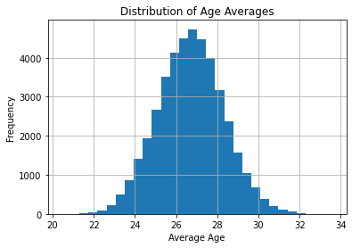

```python
# Let's see what kind of distribution do we have for age, weight and height. Age first
df_questions["age_avg"].hist(bins=30)
plt.xlabel("Average Age"),plt.ylabel("Frequency")
plt.title("Distribution of Age Averages");
```

It resembles a normal distribution of age averages.

```python
df_questions["age_avg"].describe()
```

```
count    42748.000000
mean        26.709170
std          1.595014
min         20.424537
25%         25.628054
50%         26.715252
75%         27.770342
max         33.606315
Name: age_avg, dtype: float64
```

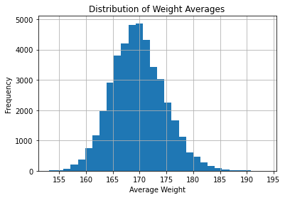

```python
# Let's see what kind of distribution do we have for weight now
df_questions["weight_avg"].hist(bins=30)
plt.xlabel("Average Weight"),plt.ylabel("Frequency")
plt.title("Distribution of Weight Averages");
```

This one is slightly skewed to the right.

```python
df_questions["weight_avg"].describe()
```

```
count    42748.000000
mean       169.737917
std          4.915714
min        153.090909
25%        166.363636
50%        169.545455
75%        172.818182
max        193.454545
Name: weight_avg, dtype: float64
```

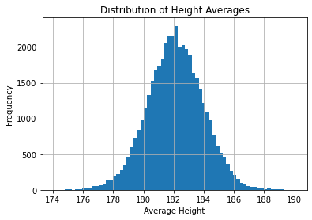

```python
# Let's see what kind of distribution do we have for height
df_questions["height_avg"].hist(bins=70)
plt.xlabel("Average Height"),plt.ylabel("Frequency")
plt.title("Distribution of Height Averages");
```

I had increase the number of bins in order to understand the data better because it has more noise, and we can see that there is a normal distribution with a large number of bins, something that's hard to notice with a smaller number.

```python
df_questions["height_avg"].describe()
```

```
count    42748.000000
mean       182.127104
std          1.872949
min        174.105455
25%        180.801818
50%        182.187273
75%        183.341818
max        190.038182
Name: height_avg, dtype: float64
```

It's quite normal to have a normal distribution of averages of averages, given a big enough sample. So everything seems as expected, so far.

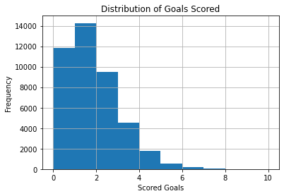

```python
# Let's also understand the distribution of the results. Starting with goals scored (which should be the same as goals suffered)
df_questions["goals_scored"].hist()
plt.xlabel("Scored Goals"),plt.ylabel("Frequency")
plt.title("Distribution of Goals Scored");
```

```python
print("Number of goals most commonly scored: ",df_questions["goals_scored"].mode()[0])
print(df_questions["goals_scored"].describe())
```

```
Number of goals most commonly scored:  1
count    42748.000000
mean         1.366169
std          1.244008
min          0.000000
25%          0.000000
50%          1.000000
75%          2.000000
max         10.000000
Name: goals_scored, dtype: float64
```

```python
# Let's know the number of wins and losses. This is per team and not per match, so W and L should be the same, but not D.
df_questions.groupby("result")["team_api_id"].count()
```

```
result
D    10796
L    15976
W    15976
Name: team_api_id, dtype: int64
```

```python
print("Rate of Draws: ", round(((df_questions.query('result == "D"').count()[0])/2) /df_questions["match_api_id"].nunique(),2))
```

```
Rate of Draws:  0.25
```

So around 25% of the matches end as a draw.

Let's now see how age, weight and height correlate to each other.

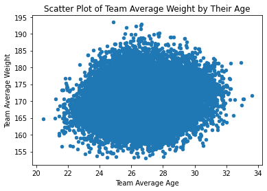

```python
df_questions.plot(x="age_avg",y="weight_avg",kind="scatter",title="Scatter Plot of Team Average Weight by Their Age",\
                  xlabel="Team Average Age",ylabel="Team Average Weight");
```

No correlation between the two.

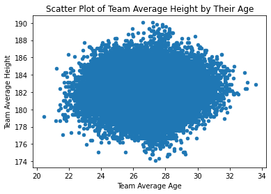

```python
df_questions.plot(x="age_avg",y="height_avg",kind="scatter",title="Scatter Plot of Team Average Height by Their Age",\
                  xlabel="Team Average Age",ylabel="Team Average Height");
```

No correlation between the two.

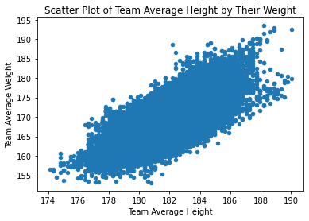

```python
df_questions.plot(x="height_avg",y="weight_avg",kind="scatter",title="Scatter Plot of Team Average Height by Their Weight",\
                  xlabel="Team Average Height",ylabel="Team Average Weight");
```

Clear correlation here. Taller teams are usually heavier, which is normal because height implies more weight in a body. This would be very important to note if we wanted to find causation in our results (but it's not the case).

### Research Question 1: How do team results tend to differ by team overall age?

```python
# Now we'll get into our question and see differences between groups of ages
df_questions.groupby("age_cat").mean()
```

| age_cat | match_api_id | goals_scored | goals_suff | team_api_id | age_avg | weight_avg | height_avg | goal_dif |
| --- | --- | --- | --- | --- | --- | --- | --- | --- |
| very_young | 1.260164e+06 | 1.437371 | 1.394870 | 10187.670099 | 24.682590 | 169.230924 | 182.177199 | 0.042501 |
| young | 1.259531e+06 | 1.373503 | 1.389128 | 10341.785180 | 26.192236 | 169.536226 | 182.088799 | -0.015625 |
| old | 1.250115e+06 | 1.350922 | 1.347460 | 9903.217513 | 27.222696 | 169.720307 | 182.040203 | 0.003462 |
| very_old | 1.236467e+06 | 1.302928 | 1.333240 | 9619.291889 | 28.737782 | 170.463858 | 182.202243 | -0.030312 |

```python
df_questions.groupby("age_cat").std()
```

| age_cat | match_api_id | goals_scored | goals_suff | team_api_id | age_avg | weight_avg | height_avg | goal_dif |
| --- | --- | --- | --- | --- | --- | --- | --- | --- |
| very_young | 461158.542803 | 1.283464 | 1.263090 | 15456.645933 | 0.756032 | 4.909159 | 1.815283 | 1.894876 |
| young | 482507.072001 | 1.252413 | 1.264963 | 15578.117820 | 0.311904 | 4.954740 | 1.861985 | 1.860595 |
| old | 490062.989401 | 1.242217 | 1.220518 | 11933.899317 | 0.302530 | 4.896964 | 1.943519 | 1.806790 |
| very_old | 487568.814659 | 1.192664 | 1.225852 | 9503.017673 | 0.814710 | 4.817599 | 1.864377 | 1.767031 |

It seems that the **number of goals scored droped with age**, but it's not alone, since the **number of goals suffered also droped with age**. Their **goal difference was also lower with age, being positive in younger teams and negative in older.**

Let's use a scatter plot to see the how these are distributed along with age. Since we're not going to use the age groups this time, it'll be normal to find a higher variety of results near the mean, due to a bigger sample, so I'm curious to see if there's any unexpected result.

Let's see what we get

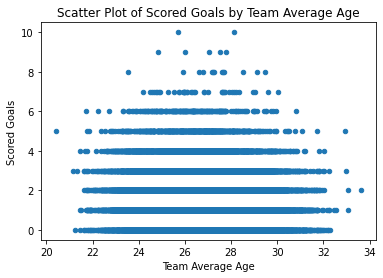

```python
df_questions.plot(x="age_avg",y="goals_scored",kind="scatter",title="Scatter Plot of Scored Goals by Team Average Age",\
                  xlabel="Team Average Age",ylabel="Scored Goals");
```

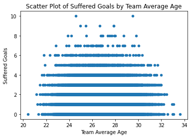

```python
df_questions.plot(x="age_avg",y="goals_suff",kind="scatter",title="Scatter Plot of Suffered Goals by Team Average Age",\
                  xlabel="Team Average Age",ylabel="Suffered Goals");
```

As we can see, the matches where there are a lot of goals (wether scored or suffered) usually have teams whose players' age are around the average, but it's also most of the teams, so it's as expected and not necesseraly related to age.

What about goal difference?

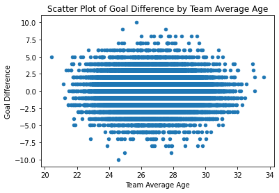

```python
df_questions.plot(x="age_avg",y="goal_dif",kind="scatter",title="Scatter Plot of Goal Difference by Team Average Age",\
                  xlabel="Team Average Age",ylabel="Goal Difference");
```

The highest goal difference (wether positive or negative) is near the average of the team's mean age. Still as expected, because of sample distribution. Although this time it looks like it's closer to 0 on older teams than on younger ones.

Now let's see the differences between final results

```python
# Differences between age groups on wins, losses and draws

df_questions.groupby(["age_cat","result"])["team_api_id"].count()
```

```
age_cat     result
very_young  D         2594
            L         3972
            W         4116
young       D         2707
            L         3983
            W         3998
old         D         2770
            L         3964
            W         3955
very_old    D         2725
            L         4057
            W         3907
Name: team_api_id, dtype: int64
```

This is a bit hard to read, so I'll create a line graph to understand it better

```python
# We'll have to repeat this task a couple of times, so let's create a function for it
#I'm going to need this list
match_result_labels = ["D","L","W"]

#I'll need a function to create a data frame with filtered results from df_question
def df_generator(column_for_ratio, ratio_labels):
    '''
    Returns new dataframes for every label we want

        Parameters:
            column_for_ratio(str): column we want to filter, must be within quotation marks
            ratio_labels(list): labels we want to get a dataframe from, must be present in column_for_ratio

        Returns:
            df_[label]: a new dataframe for each label within ratio_labels,a dn print their names

    '''
    for label in ratio_labels:
        globals()['df_%s' %label] = df_questions[df_questions[column_for_ratio] == str(label)]
        print("Generated: df_"+str(label))
```

```python
# Now I'll need a function that will find the ratios we want

def find_ratio(column_categories, ratio_labels):
    '''
    Returns ratios for labels in every category defined

        Parameters:
            column_categories(str): Name of the column with categories we want to see the ratios in. Must be in quotation marks
            ratio_labels(list): labels that we want to know the ratio, per category in column_categories

        Returns:
            [label]_ratio_[column_category]: A new variable which contains the ratio of the label within a category and print it
    '''
    for label in ratio_labels:
        globals()['%s_ratio_%s' %(label, column_categories)] = globals()['df_%s' %label].groupby(column_categories)\
        .team_api_id.count() / df_questions.groupby(column_categories).team_api_id.count()
        print("Found the ratio: "+str(label)+"_ratio_"+str(column_categories))
```

```python
# Let's put them to practice

df_generator("result",match_result_labels)
find_ratio("age_cat",match_result_labels)
```

```
Generated: df_D
Generated: df_L
Generated: df_W
Found the ratio: D_ratio_age_cat
Found the ratio: L_ratio_age_cat
Found the ratio: W_ratio_age_cat
```

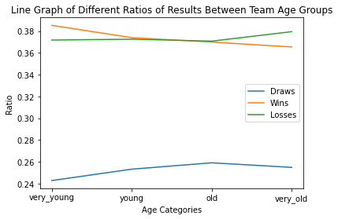

```python
# Now we'll plot all ratios and see how they differ by age category

plt.plot(age_labels, D_ratio_age_cat, label="Draws")
plt.plot(age_labels, W_ratio_age_cat, label="Wins")
plt.plot(age_labels, L_ratio_age_cat, label="Losses")
plt.legend()
plt.title("Line Graph of Different Ratios of Results Between Team Age Groups")
plt.xlabel("Age Categories")
plt.ylabel("Ratio");
```

We can see that the **ratio of wins was lower as the team was older**, while the **ratio of losses was higher with age** (although it's only visible on the oldest category). The ratio of draws have also grown till a certain point.

Let's invert the question and look at how age differs between winning, losing at drawing teams.

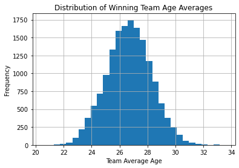

```python
# First, look at the distribution of age, within the winning teams
df_W["age_avg"].hist(bins=30);
plt.xlabel("Team Average Age"),plt.ylabel("Frequency")
plt.title("Distribution of Winning Team Age Averages");
```

```python
df_W["age_avg"].describe()
```

```
count    15976.000000
mean        26.666585
std          1.606293
min         20.424537
25%         25.591466
50%         26.681899
75%         27.742714
max         33.606315
Name: age_avg, dtype: float64
```

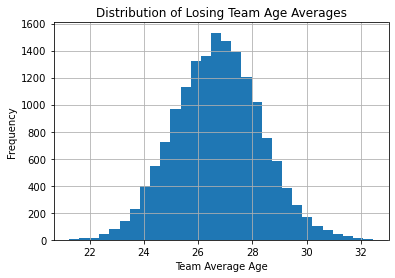

```python
# Distribution of age, within the losing teams
df_L["age_avg"].hist(bins=30);
plt.xlabel("Team Average Age"),plt.ylabel("Frequency")
plt.title("Distribution of Losing Team Age Averages");
```

```python
df_L["age_avg"].describe()
```

```
count    15976.000000
mean        26.725478
std          1.587815
min         21.237945
25%         25.632721
50%         26.723217
75%         27.783845
max         32.462368
Name: age_avg, dtype: float64
```

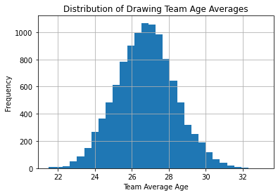

```python
# Distribution of age, within the teams with draws
df_D["age_avg"].hist(bins=30);
plt.xlabel("Team Average Age"),plt.ylabel("Frequency")
plt.title("Distribution of Drawing Team Age Averages");
```

```python
df_D["age_avg"].describe()
```

```
count    10796.000000
mean        26.748053
std          1.587585
min         21.484854
25%         25.675781
50%         26.750347
75%         27.782787
max         33.078148
Name: age_avg, dtype: float64
```

They all seem very similar, so there are hardly any differences between winning, losing and drawing teams, in terms of distribution and various discriptive statistics.

Let's now see how winning, losing and drawing teams differ in age.

```python
# We'll use our amazing functions
df_generator("age_cat",age_labels)
find_ratio("result",age_labels)
```

```
Generated: df_very_young
Generated: df_young
Generated: df_old
Generated: df_very_old
Found the ratio: very_young_ratio_result
Found the ratio: young_ratio_result
Found the ratio: old_ratio_result
Found the ratio: very_old_ratio_result
```

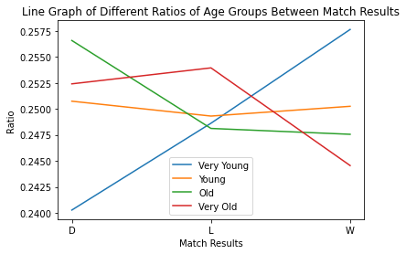

```python
# Now we'll plot all ratios and see how they differ by match result

plt.plot(match_result_labels, very_young_ratio_result, label="Very Young")
plt.plot(match_result_labels, young_ratio_result, label="Young")
plt.plot(match_result_labels, old_ratio_result, label="Old")
plt.plot(match_result_labels, very_old_ratio_result, label="Very Old")
plt.legend()
plt.title("Line Graph of Different Ratios of Age Groups Between Match Results")
plt.xlabel("Match Results")
plt.ylabel("Ratio");
```

This gives us new information. So **in the winning teams, we can find younger teams (especially the youngest) more often than the older teams**, in terms of ratio.

**In losing teams**, however, all age groups are very close to each other, but **it's more often to find the oldest teams** (in fact, more often to find them there then in everywhere else.

**In draws** I would highlight the **low ratio of the youngest teams**.

### Research Question 2: How do team results tend to differ by team overall weight?

```python
# let's see differences between groups of weights
df_questions.groupby("weight_cat").mean()
```

| weight_cat | match_api_id | goals_scored | goals_suff | team_api_id | age_avg | weight_avg | height_avg | goal_dif |
| --- | --- | --- | --- | --- | --- | --- | --- | --- |
| very_light | 1.356279e+06 | 1.305229 | 1.383998 | 11333.760252 | 26.476464 | 163.654605 | 180.438425 | -0.078769 |
| light | 1.287475e+06 | 1.354854 | 1.377970 | 10300.786425 | 26.597029 | 167.958455 | 181.651129 | -0.023117 |
| heavy | 1.219091e+06 | 1.390673 | 1.343107 | 9270.481802 | 26.802193 | 171.094412 | 182.468069 | 0.047566 |
| very_heavy | 1.145227e+06 | 1.412690 | 1.359910 | 9173.928879 | 26.957402 | 176.137512 | 183.921079 | 0.052779 |

```python
df_questions.groupby("weight_cat").std()
```

| weight_cat | match_api_id | goals_scored | goals_suff | team_api_id | age_avg | weight_avg | height_avg | goal_dif |
| --- | --- | --- | --- | --- | --- | --- | --- | --- |
| very_light | 483194.975633 | 1.217637 | 1.267949 | 20358.123166 | 1.521313 | 2.194968 | 1.499936 | 1.831191 |
| light | 469254.572570 | 1.237398 | 1.251427 | 16041.567893 | 1.597062 | 0.911633 | 1.315223 | 1.822237 |
| heavy | 467926.662208 | 1.244064 | 1.220340 | 5822.760207 | 1.589566 | 0.961519 | 1.324201 | 1.824722 |
| very_heavy | 476432.126133 | 1.273393 | 1.236089 | 3209.694209 | 1.626131 | 2.815156 | 1.397670 | 1.851386 |

This is a bit different from before. It looks like **heavier teams scored more goals and suffered less**. This is also a lot clearer if we look at the **goal difference, because it's below 0 in lighter teams and positive in heavier teams**.

The standard deviation also dropped a bit in goals suffered, so **heavier teams seem to have defended better and more consistently**, which doesn't happen with scored goals.

So it looks like heavier teams have better results, but let's look at this in a different perspective.

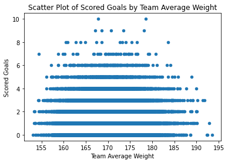

```python
df_questions.plot(x="weight_avg",y="goals_scored",kind="scatter",title="Scatter Plot of Scored Goals by Team Average Weight",\
                  xlabel="Team Average Weight",ylabel="Scored Goals");
```

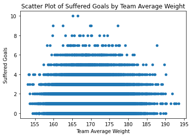

```python
df_questions.plot(x="weight_avg",y="goals_suff",kind="scatter",title="Scatter Plot of Suffered Goals by Team Average Weight",\
                  xlabel="Team Average Weight",ylabel="Suffered Goals");
```

Once again, nothing out of the ordinary because of weight distribution.

And goal difference?

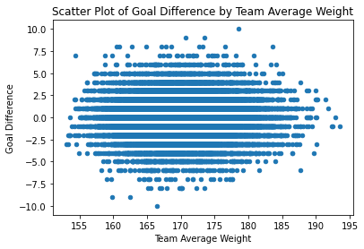

```python
df_questions.plot(x="weight_avg",y="goal_dif",kind="scatter",title="Scatter Plot of Goal Difference by Team Average Weight",\
                  xlabel="Team Average Weight",ylabel="Goal Difference");
```

Everything as expected, so nothing to point out that may be relevant.

Let's see how different weight teams differ in their matches' results.

```python
# We already have the dataframes of match results, so let's just create the new ratios
find_ratio("weight_cat",match_result_labels)
```

```
Found the ratio: D_ratio_weight_cat
Found the ratio: L_ratio_weight_cat
Found the ratio: W_ratio_weight_cat
```

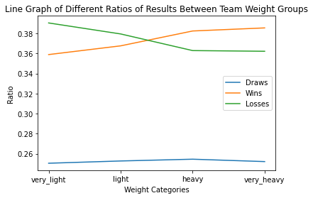

```python
# Plot a line graph with results' ratio
plt.plot(weight_labels, D_ratio_weight_cat, label="Draws")
plt.plot(weight_labels, W_ratio_weight_cat, label="Wins")
plt.plot(weight_labels, L_ratio_weight_cat, label="Losses")
plt.legend()
plt.title("Line Graph of Different Ratios of Results Between Team Weight Groups")
plt.xlabel("Weight Categories")
plt.ylabel("Ratio");
```

Looks like **lighter teams have lost more matches than what they have won, and heavier teams have won more matches than what they have lost**.

Let's invert this question and see how winning, losing and drawing teams differ in weight.

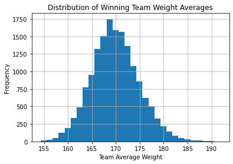

```python
# First, look at the distribution of weight, within the winning teams
df_W["weight_avg"].hist(bins=30);
plt.xlabel("Team Average Weight"),plt.ylabel("Frequency")
plt.title("Distribution of Winning Team Weight Averages");
```

```python
df_W["weight_avg"].describe()
```

```
count    15976.000000
mean       169.869395
std          4.957476
min        154.272727
25%        166.545455
50%        169.636364
75%        173.000000
max        191.818182
Name: weight_avg, dtype: float64
```

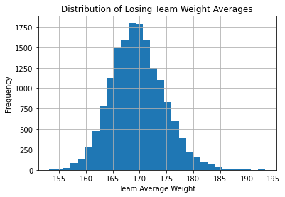

```python
# Look at the distribution of weight, within the losing teams
df_L["weight_avg"].hist(bins=30);
plt.xlabel("Team Average Weight"),plt.ylabel("Frequency")
plt.title("Distribution of Losing Team Weight Averages");
```

Slightly skewed to the right.

```python
df_L["weight_avg"].describe()
```

```
count    15976.000000
mean       169.598807
std          4.911057
min        153.090909
25%        166.272727
50%        169.363636
75%        172.727273
max        193.454545
Name: weight_avg, dtype: float64
```

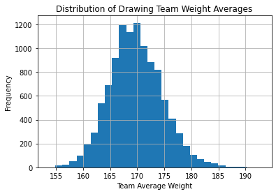

```python
# Distribution of weight, within the teams with draws
df_D["weight_avg"].hist(bins=30);
plt.xlabel("Team Average Weight"),plt.ylabel("Frequency")
plt.title("Distribution of Drawing Team Weight Averages");
```

```python
df_D["weight_avg"].describe()
```

```
count    10796.000000
mean       169.749208
std          4.855090
min        153.545455
25%        166.454545
50%        169.545455
75%        172.818182
max        192.818182
Name: weight_avg, dtype: float64
```

```python
# Create new dataframes for each weight label
df_generator("weight_cat",weight_labels)

# Find ratios
find_ratio("result",weight_labels)
```

```
Generated: df_very_light
Generated: df_light
Generated: df_heavy
Generated: df_very_heavy
Found the ratio: very_light_ratio_result
Found the ratio: light_ratio_result
Found the ratio: heavy_ratio_result
Found the ratio: very_heavy_ratio_result
```

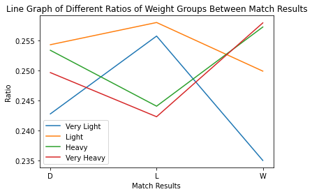

```python
# Now we'll plot all ratios and see how they differ by match result

plt.plot(match_result_labels, very_light_ratio_result, label="Very Light")
plt.plot(match_result_labels, light_ratio_result, label="Light")
plt.plot(match_result_labels, heavy_ratio_result, label="Heavy")
plt.plot(match_result_labels, very_heavy_ratio_result, label="Very Heavy")
plt.legend()
plt.title("Line Graph of Different Ratios of Weight Groups Between Match Results")
plt.xlabel("Match Results")
plt.ylabel("Ratio");
```

Let's focus on winning and losing teams first and we can see a trend. The ratio of lighter teams grows in the losing matches group, so much that they are most common to find. In order words, **in losing teams it's most common to find lighter teams**.

**In the winning group**, however, the **heavier teams are more common than lighter teams, especially comparing to the lightest teams**.

**In draws**, it's hard to differenciate, but **the lightest teams are less present there.**

### Research Question 3: How do team results tend to differ by team overall height?

```python
# let's see differences between groups of heights
df_questions.groupby("height_cat").mean()
```

| height_cat | match_api_id | goals_scored | goals_suff | team_api_id | age_avg | weight_avg | height_avg | goal_dif |
| --- | --- | --- | --- | --- | --- | --- | --- | --- |
| very_short | 1.248005e+06 | 1.338219 | 1.354067 | 10614.702180 | 26.682961 | 165.375429 | 179.780390 | -0.015848 |
| short | 1.255495e+06 | 1.338197 | 1.371302 | 10119.192795 | 26.689846 | 168.410298 | 181.521591 | -0.033105 |
| tall | 1.269720e+06 | 1.394623 | 1.369769 | 9982.084538 | 26.723861 | 170.711971 | 182.728266 | 0.024854 |
| very_tall | 1.230221e+06 | 1.390661 | 1.369995 | 9291.712866 | 26.739408 | 174.635352 | 184.563583 | 0.020666 |

```python
df_questions.groupby("height_cat").std()
```

| height_cat | match_api_id | goals_scored | goals_suff | team_api_id | age_avg | weight_avg | height_avg | goal_dif |
| --- | --- | --- | --- | --- | --- | --- | --- | --- |
| very_short | 479162.104018 | 1.229776 | 1.260504 | 16388.032454 | 1.536416 | 3.477626 | 0.976291 | 1.831076 |
| short | 468826.531710 | 1.225518 | 1.234582 | 13681.929312 | 1.591524 | 3.230786 | 0.322967 | 1.807705 |
| tall | 481706.691656 | 1.265683 | 1.238222 | 13908.810279 | 1.615987 | 3.455462 | 0.391766 | 1.848202 |
| very_tall | 491137.078684 | 1.250672 | 1.242151 | 7371.284026 | 1.635050 | 4.206750 | 0.941152 | 1.841971 |

**Taller teams seem to have scored more, on average**.

In terms of suffered goals, it's hard to find differences between them, since they are small.

Perhaps because of that, we can see that shorter teams had a negative goal difference, while taller teams had a positive one. So **taller teams seem to have scored more than have suffered goals** and **shorter teams seem to have suffered more goals than what they have scored**.

Let's if there's something out of ordinary in goals distribution by height.

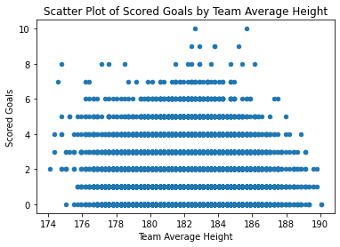

```python
df_questions.plot(x="height_avg",y="goals_scored",kind="scatter",title="Scatter Plot of Scored Goals by Team Average Height",\
                  xlabel="Team Average Height",ylabel="Scored Goals");
```

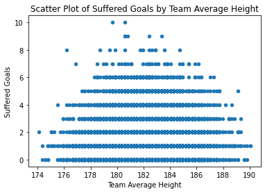

```python
df_questions.plot(x="height_avg",y="goals_suff",kind="scatter",title="Scatter Plot of Suffered Goals by Team Average Height",\
                  xlabel="Team Average Height",ylabel="Suffered Goals");
```

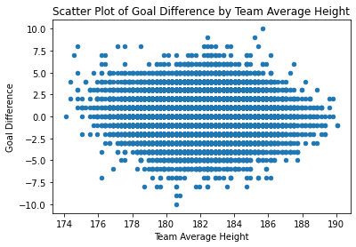

```python
df_questions.plot(x="height_avg",y="goal_dif",kind="scatter",title="Scatter Plot of Goal Difference by Team Average Height",\
                  xlabel="Team Average Height",ylabel="Goal Difference");
```

Let's see how different height teams differ in matches' results.

```python
# We have the dataframes needed, let's get the ratios
find_ratio("height_cat",match_result_labels)
```

```
Found the ratio: D_ratio_height_cat
Found the ratio: L_ratio_height_cat
Found the ratio: W_ratio_height_cat
```

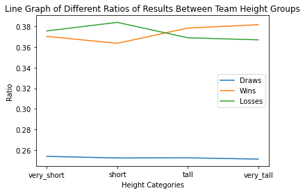

```python
# Plot a line graph with results' ratio
plt.plot(height_labels, D_ratio_height_cat, label="Draws")
plt.plot(height_labels, W_ratio_height_cat, label="Wins")
plt.plot(height_labels, L_ratio_height_cat, label="Losses")
plt.legend()
plt.title("Line Graph of Different Ratios of Results Between Team Height Groups")
plt.xlabel("Height Categories")
plt.ylabel("Ratio");
```

Let's invert this and see how winning, losing and drawing teams differ in height.

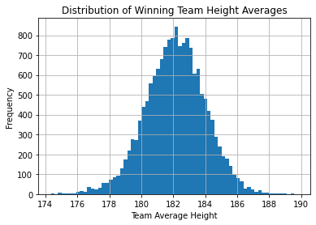

```python
# Distribution of height, within the winning teams
df_W["height_avg"].hist(bins=68);
plt.xlabel("Team Average Height"),plt.ylabel("Frequency")
plt.title("Distribution of Winning Team Height Averages");
```

```python
df_W["height_avg"].describe()
```

```
count    15976.000000
mean       182.132667
std          1.904362
min        174.336364
25%        180.801818
50%        182.187273
75%        183.341818
max        189.807273
Name: height_avg, dtype: float64
```

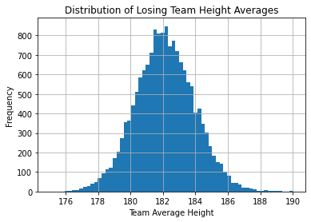

```python
# Distribution of height, within the losing teams
df_L["height_avg"].hist(bins=66);
plt.xlabel("Team Average Height"),plt.ylabel("Frequency")
plt.title("Distribution of Losing Team Height Averages");
```

```python
df_L["height_avg"].describe()
```

```
count    15976.000000
mean       182.119775
std          1.849677
min        175.029091
25%        180.801818
50%        182.187273
75%        183.341818
max        190.038182
Name: height_avg, dtype: float64
```

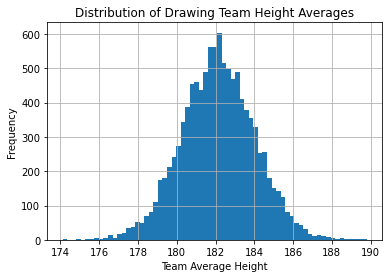

```python
# Distribution of height, within the teams with draws
df_D["height_avg"].hist(bins=67);
plt.xlabel("Team Average Height"),plt.ylabel("Frequency")
plt.title("Distribution of Drawing Team Height Averages");
```

```python
df_D["height_avg"].describe()
```

```
count    10796.000000
mean       182.129717
std          1.860392
min        174.105455
25%        180.801818
50%        182.187273
75%        183.341818
max        189.807273
Name: height_avg, dtype: float64
```

Because height values are not as diversed as age or weight (as we could see with the distribution of height where a bigger number a bins was necessary), I had to define different numbers of bins to reach the solution with less noise. But its distribution is close to a normal one, regardless of the result group.

```python
# Create the dataframes for each height category
df_generator("height_cat",height_labels)

# Find the needed ratios
find_ratio("result",height_labels)
```

```
Generated: df_very_short
Generated: df_short
Generated: df_tall
Generated: df_very_tall
Found the ratio: very_short_ratio_result
Found the ratio: short_ratio_result
Found the ratio: tall_ratio_result
Found the ratio: very_tall_ratio_result
```

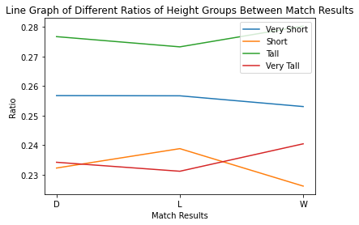

```python
# Now we'll plot all rates and see how they differ by match result

plt.plot(match_result_labels, very_short_ratio_result, label="Very Short")
plt.plot(match_result_labels, short_ratio_result, label="Short")
plt.plot(match_result_labels, tall_ratio_result, label="Tall")
plt.plot(match_result_labels, very_tall_ratio_result, label="Very Tall")
plt.legend()
plt.title("Line Graph of Different Ratios of Height Groups Between Match Results")
plt.xlabel("Match Results")
plt.ylabel("Ratio");
```

However, since the short and very tall groups have frequencies more close to each other we can compare them, and we can see that **in the losing teams we can find more short teams than the tallest ones, but only with a small difference**.

**In winning teams we can find more of the tallest teams than of the short teams**.

## Conclusions

**Research Question 1: How do team results tend to differ by team overall age?**

I've found out that in the present data:

- The average number of goals scored and suffered were lower in older teams and higher in younger ones.In other words, older teams scored and suffered less goals than younger ones;
- The ratio of wins is lower in older teams, while the ratio of losses is higher.
- Also, we can find more often younger teams in the winning group than older teams, and the oldest teams are also more common in the losing group.

Summary: So, although older teams have suffered less goals, everything else was worst for them, less goals scored, lost more than they have won and even when we compare between the age categories they lose more frequently and win less. It seems like younger teams were the clear winners in terms of match results statistics.

**Research Question 2: How do team results tend to differ by team overall weight?**

I've found out that in the present data:

- Heavier teams, on average, scored more goals and suffered less;
- Lighter teams lost more matches than what they have won, and heavier teams have won more matches than lost;
- There are more lighter teams in the losing group and the heavier teams are more common in the winning group.

Summary: So heavier teams seem to have scored more goals, suffered less, won more games than the ones they lost and are weight category most present in winning teams. The lightest group, however, is the opposite, so it looks like heavier teams were the clear winners in terms of match results

**Research Question 3: How do team results tend to differ by team overall height?**

Summary: Tallest teams seem to have scored more and, compared to the short teams, were the ones more often to win the game and less often to lose, so it looks like they were the better teams, but there are small differences in most of the data.

**Additional Research**

- It would be important to know if these differences we have found are actually statisticaly significant, because they might not be strong enough;
- Professional soccer teams don't have many differences between ages, weight and height, so it would be interesting to have data on non professional matches, which should have a higher variety of those values between players.
- I would also like to do a lot more reasearch on the other tables, like with the Player_Attributes table, but a lot of information is stored in xml so it would require more time for me to do it, since I am not at ease with that type of language, yet.

### Limitations

Because the distribution of height values is not much broad, it was hard to define height groups with around the same number of teams. That made it hard to compare between groups since their ratios were off, not because of actual performance results, but simply because there were more teams in certain groups than others.

It's also important to note that while we can easily update age between match seasons, since we have the birthday date of each player and not an age number in our source of information, we can't do the same with height and weight values. I don't have any information about when these values were assessed, and there are no updates between seasons, so my conclusions regarding height and weight data are not realistic because players could have different values for each match and we are not aware of that.